# Wine Quality Data

Classification Modeling

Kimberly Healy | healy.kim@gmx.us

## Background

The data ([WineQuality.csv](https://archive.ics.uci.edu/ml/datasets/wine+quality)) includes the results of physicochemical and sensory tests for different types of wine. The attributes from the physicochemical tests include: fixed acidity, volatile acidity, citric acid, residual sugar, chlorides, free sulfur dioxide, total sulfur dioxide, density, pH, sulphates, alcohol, wine type. The attribute from the sensory test includes: quality, a score between 0 and 10.

The purpose of this investigation is to find the optimal classification model to predict wine quality. The variables in the raw data set include:

| Variable | Type |
| --- | --- |
| fixed.acidity | numeric |
| volatile.acidity | numeric |
| citric.acid | numeric |
| residual.sugar | numeric |
| chlorides | numeric |
| free.sulfur.dioxide | numeric |
| total.sulfer.dioxide | numeric |
| density | numeric |
| pH | numeric |
| sulphates | numeric |
| alcohol | numeric (%) |
| winetype | string, red or white |
| quality | integer, ordinal rating between 0 and 10 |

The following predictive models are used for a categorical output:  
**Model 1: Ordered Logistic Regression**: A regression model with an ordinal dependent variable.  
**Model 2: CART (tree)**: Classification & regression tree that takes a either categorical or continuous response variable. At an inner node, it allows a binary split.  
**Model 3: C5.0 (tree)**: Classification tree that takes only a categorical response variable. At an inner node, it allows a multiple split. Each node is split using the best split by the Gini Index among all input variables.  
**Model 4: Random Forest (tree)**: Combines multiple models (i.e. hundreds of decision trees) into a single ensemble. Each decision tree is independent from another tree. Each node is split using the best split among a random subset of all input predictor variables chosen at the node.

The following questions are answered:  
- **Which attributes best predict wine quality?**  
- **Which model(s) best predicts wine quality?**

## I. Load required libraries

```r
library(tidyverse)
library(rpart)
library(caret)
library(e1071)
library(C50)
library(randomForest)
```

## II. Load raw data from csv file

```r
wine_raw <- read.csv("WineQuality.csv", sep=",")
wine <- wine_raw
```

## III. Define Useful Functions

### (i) Significance Tests

$H_{o}: \rho = 0$  
$H_{a}: \rho ≠ 0$

```r
# correlation test
cor.mtest <- function(mat, ...) {
    mat <- as.matrix(mat)
    n <- ncol(mat)
    p.mat<- matrix(NA, n, n)
    diag(p.mat) <- 0
    for (i in 1:(n - 1)) {
        for (j in (i + 1):n) {
            tmp <- cor.test(mat[, i], mat[, j], ...)
            p.mat[i, j] <- p.mat[j, i] <- tmp$p.value
        }
    }
    colnames(p.mat) <- rownames(p.mat) <- colnames(mat)
    p.mat
}
```

## IV. Data Preprocessing & Exploration

### (i) Preprocessing

#### Summary

The data is pretty clean in its raw state.

```r
dim(wine)
```

```
## [1] 6497   13
```

```r
summary(wine)
```

```
##  fixed.acidity    volatile.acidity  citric.acid     residual.sugar
##  Min.   : 3.800   Min.   :0.0800   Min.   :0.0000   Min.   : 0.600
##  1st Qu.: 6.400   1st Qu.:0.2300   1st Qu.:0.2500   1st Qu.: 1.800
##  Median : 7.000   Median :0.2900   Median :0.3100   Median : 3.000
##  Mean   : 7.215   Mean   :0.3397   Mean   :0.3186   Mean   : 5.443
##  3rd Qu.: 7.700   3rd Qu.:0.4000   3rd Qu.:0.3900   3rd Qu.: 8.100
##  Max.   :15.900   Max.   :1.5800   Max.   :1.6600   Max.   :65.800
##    chlorides       free.sulfur.dioxide total.sulfur.dioxide    density
##  Min.   :0.00900   Min.   :  1.00      Min.   :  6.0        Min.   :0.9871
##  1st Qu.:0.03800   1st Qu.: 17.00      1st Qu.: 77.0        1st Qu.:0.9923
##  Median :0.04700   Median : 29.00      Median :118.0        Median :0.9949
##  Mean   :0.05603   Mean   : 30.52      Mean   :115.7        Mean   :0.9947
##  3rd Qu.:0.06500   3rd Qu.: 41.00      3rd Qu.:156.0        3rd Qu.:0.9970
##  Max.   :0.61100   Max.   :289.00      Max.   :440.0        Max.   :1.0390
##        pH          sulphates         alcohol       winetype       quality
##  Min.   :2.720   Min.   :0.2200   Min.   : 8.00   red  :1599   Min.   :3.000
##  1st Qu.:3.110   1st Qu.:0.4300   1st Qu.: 9.50   white:4898   1st Qu.:5.000
##  Median :3.210   Median :0.5100   Median :10.30                Median :6.000
##  Mean   :3.219   Mean   :0.5313   Mean   :10.49                Mean   :5.818
##  3rd Qu.:3.320   3rd Qu.:0.6000   3rd Qu.:11.30                3rd Qu.:6.000
##  Max.   :4.010   Max.   :2.0000   Max.   :14.90                Max.   :9.000
```

```r
str(wine)
```

```
## 'data.frame':    6497 obs. of  13 variables:
##  $ fixed.acidity       : num  7.4 7.8 7.8 11.2 7.4 7.4 7.9 7.3 7.8 7.5 ...
##  $ volatile.acidity    : num  0.7 0.88 0.76 0.28 0.7 0.66 0.6 0.65 0.58 0.5 ...
##  $ citric.acid         : num  0 0 0.04 0.56 0 0 0.06 0 0.02 0.36 ...
##  $ residual.sugar      : num  1.9 2.6 2.3 1.9 1.9 1.8 1.6 1.2 2 6.1 ...
##  $ chlorides           : num  0.076 0.098 0.092 0.075 0.076 0.075 0.069 0.065 0.073 0.071 ...
##  $ free.sulfur.dioxide : int  11 25 15 17 11 13 15 15 9 17 ...
##  $ total.sulfur.dioxide: int  34 67 54 60 34 40 59 21 18 102 ...
##  $ density             : num  0.998 0.997 0.997 0.998 0.998 ...
##  $ pH                  : num  3.51 3.2 3.26 3.16 3.51 3.51 3.3 3.39 3.36 3.35 ...
##  $ sulphates           : num  0.56 0.68 0.65 0.58 0.56 0.56 0.46 0.47 0.57 0.8 ...
##  $ alcohol             : num  9.4 9.8 9.8 9.8 9.4 9.4 9.4 10 9.5 10.5 ...
##  $ winetype            : Factor w/ 2 levels "red","white": 1 1 1 1 1 1 1 1 1 1 ...
##  $ quality             : int  5 5 5 6 5 5 5 7 7 5 ...
```

```r
length(which(is.na(wine)))
```

```
## [1] 0
```

```r
# change to appropriate data types
wine$free.sulfur.dioxide<-as.numeric(wine$free.sulfur.dioxide)
wine$total.sulfur.dioxide<-as.numeric(wine$total.sulfur.dioxide)
wine$quality<-as.factor(wine$quality)

# convert winetype (red, white) attribute to numeric binary
wine$winetype<-ifelse(wine$winetype == "red", 0, 1)
```

#### Create wine.bin

Bin wine quality ratings for classification models

```r
wine$quality.bin<-as.character(wine$quality)
wine$quality.bin[wine$quality.bin %in% c("0","1","2","3","4","5")] <- "OK"
wine$quality.bin[wine$quality.bin %in% c("6","7")] <- "Above Average"
wine$quality.bin[wine$quality.bin %in% c("8", "9", "10")] <- "Superior"
wine$quality.bin<-as.factor(wine$quality.bin)
```

### (ii) Exploration

#### Distributions

The data does not include any wines with quality rating 1, 2, or 10.  
Wine quality is approx. normally distributed.

```r
table(wine$quality)
```

```
##
##    3    4    5    6    7    8    9
##   30  216 2138 2836 1079  193    5
```

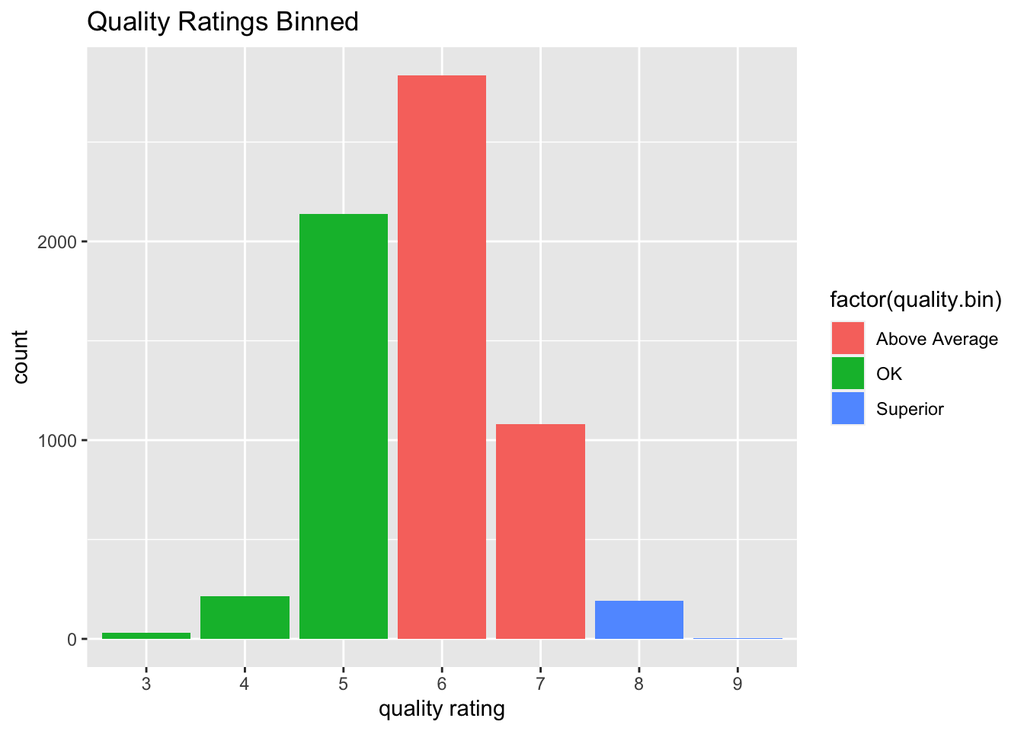

```r
ggplot(wine, aes(factor(quality), fill = factor(quality.bin))) +
  labs(title = "Quality Ratings Binned", x = "quality rating") + geom_bar()
```

Distributions of numeric variables.

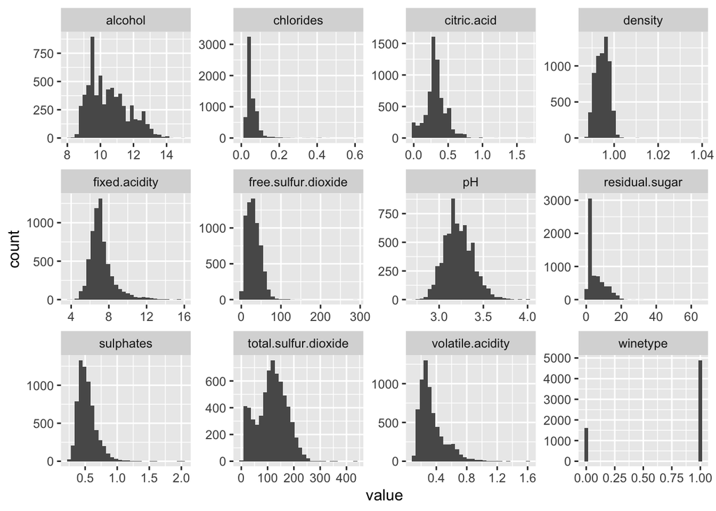

```r
wine %>%
  purrr::keep(is.numeric) %>%
  gather() %>%
  ggplot(aes(value)) +
    facet_wrap(~ key, scales = "free") +
    geom_histogram()
```

#### Correlations

Correlations between numerical variables.  
Notable correlations are between:  
- free.sulfur.dioxide and total.sulfur.dioxide (r = 0.721)  
- density and alcohol (r = -0.6867)  
- volatile.acidity and winetype (r = -0.653)  
- quality is correlated the most with alcohol (r = 0.444), although moderately so  
- quality and pH level correlation is statistically insignificant (p-val = 0.116)

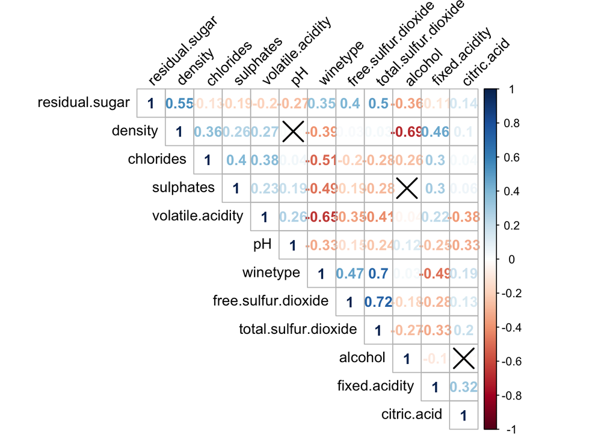

```r
# calculate p-values of correlations
p.mat <- cor.mtest(select_if(wine, is.numeric))

# plot correlations. X's indicate statistically insignificant correlation
corrplot::corrplot(cor(select_if(wine, is.numeric)),
                   method="number",
                   type="upper", order="hclust", tl.col="black", tl.srt=45,
                   p.mat = p.mat, sig.level = 0.05
)
```

#### Chi Square

Determine the relationship between the two categorical variables, winetype and quality.

p-val < 0.05, there is enough evidence to reject $H_{o}:$, the variables are dependent

```r
chi.test <- chisq.test(table(wine$winetype, wine$quality))
chi.test
```

```
##
##  Pearson's Chi-squared test
##
## data:  table(wine$winetype, wine$quality)
## X-squared = 116.54, df = 6, p-value < 2.2e-16
```

## V. Partition the data into training and testing sets

Training set = 70% data  
Testing set = 30% data

```r
samplesize = 0.70*nrow(wine)
set.seed(100)

index = sample(seq_len(nrow(wine)), size = samplesize)
wine_train = wine[index,]
wine_test = wine[-index,]
```

## VI. Modelling

### (i) Ordered Logistic Regression

#### Model

All attributes are included in the model. P-Values are calculated and included in the summary.

The coefficients are interpreted in log odds.  
- Positive log odds = more likely to be in a lower bin  
- Negative log odds = more likely to be in a higher bin

NOTE: Comparison of coefficients would be more efficient if the input variables are  
scaled over the same interval. I did not scale the input variables, so each  
coefficient in this model should be interpreted in the context of its units and  
distribution shown in (ii) Exploration: Distributions of numeric variables.

- **Coefficient interpretation example 1**: for a one unit increase in volatile.acidity, we expect the expected value of the log odds of quality.bin to increase by 3.98 (log odds of the wine being of lesser or equal quality than the current quality bin), given that all of the other variables in the model remain constant.
- **Coefficient interpretation example 2**: for a one unit increase in fixed.acidity, we expect the expected value of the log odds of quality.bin to decrease by 0.057 (log odds of the wine being of lesser or equal quality than the current quality bin), given that all of the other variables in the model remain constant.

```r
# model to predict quality bin from all other factors
wine_logit = MASS::polr(quality.bin~.,data=wine_train[,-(ncol(wine_train)-1)], Hess=TRUE)
summary(wine_logit)
```

```
## Call:
## MASS::polr(formula = quality.bin ~ ., data = wine_train[, -(ncol(wine_train) -
##     1)], Hess = TRUE)
##
## Coefficients:
##                          Value Std. Error t value
## fixed.acidity        -0.056956   0.036528  -1.559
## volatile.acidity      3.980211   0.292108  13.626
## citric.acid           0.613902   0.273608   2.244
## residual.sugar       -0.053791   0.008244  -6.525
## chlorides             1.678912   1.129407   1.487
## free.sulfur.dioxide  -0.007841   0.002739  -2.863
## total.sulfur.dioxide  0.003649   0.001131   3.227
## density              31.850007   0.536726  59.341
## pH                   -0.611050   0.253884  -2.407
## sulphates            -1.655305   0.276979  -5.976
## alcohol              -0.570472   0.036447 -15.652
## winetype              0.387312   0.173013   2.239
##
## Intercepts:
##                  Value    Std. Error t value
## Above Average|OK  24.7921   0.5461    45.4018
## OK|Superior       28.1956   0.5497    51.2925
##
## Residual Deviance: 6288.248
## AIC: 6316.248
```

```r
# p-values for variables
ctable <- coef(summary(wine_logit))
 p <- pnorm(abs(ctable[, "t value"]), lower.tail = FALSE) * 2
(ctable <- cbind(ctable, "p value" = p))
```

```
##                             Value  Std. Error    t value      p value
## fixed.acidity        -0.056956262 0.036528360  -1.559234 1.189410e-01
## volatile.acidity      3.980211222 0.292108304  13.625806 2.812856e-42
## citric.acid           0.613902465 0.273608075   2.243729 2.484982e-02
## residual.sugar       -0.053791476 0.008244440  -6.524576 6.819394e-11
## chlorides             1.678912277 1.129406579   1.486544 1.371354e-01
## free.sulfur.dioxide  -0.007841181 0.002738876  -2.862919 4.197577e-03
## total.sulfur.dioxide  0.003648862 0.001130725   3.227012 1.250900e-03
## density              31.850006673 0.536726401  59.341233 0.000000e+00
## pH                   -0.611050092 0.253883522  -2.406813 1.609242e-02
## sulphates            -1.655304556 0.276978617  -5.976290 2.282764e-09
## alcohol              -0.570472188 0.036447229 -15.652004 3.219195e-55
## winetype              0.387312370 0.173012954   2.238632 2.517986e-02
## Above Average|OK     24.792060520 0.546059413  45.401764 0.000000e+00
## OK|Superior          28.195645309 0.549703187  51.292490 0.000000e+00
```

#### Evaluation

The confusion matrix shows the performance of the ordered logistic regression model. The numbers show how many times the quality bin was identified correctly in the test data set.  
- **Misclassification Error**: 29.44%  
- **Odds Ratio (OR) interpretation 1**: For every one unit increase in citric.acid, the odds of being in a lower quality.bin is increased by 84.8% (multiplied 1.848 times), given that all of the other variables in the model remain constant.  
- **Odds Ratio (OR) interpretation 2**: For every one unit increase in pH, the odds of being in a lower quality.bin is multiplied 0.5428 times, given that all of the other variables in the model remain constant.

```r
# confusion matrix
predict_logit<-predict(wine_logit, wine_test, type="class")
confusionMatrix(wine_test$quality.bin, predict_logit)
```

```
## Confusion Matrix and Statistics
##
##                Reference
## Prediction      Above Average   OK Superior
##   Above Average          1005  174        0
##   OK                      337  371        1
##   Superior                 62    0        0
##
## Overall Statistics
##
##                Accuracy : 0.7056
##                  95% CI : (0.6849, 0.7258)
##     No Information Rate : 0.72
##     P-Value [Acc > NIR] : 0.9242
##
##                   Kappa : 0.3643
##
##  Mcnemar's Test P-Value : <2e-16
##
## Statistics by Class:
##
##                      Class: Above Average Class: OK Class: Superior
## Sensitivity                        0.7158    0.6807       0.0000000
## Specificity                        0.6813    0.7594       0.9681888
## Pos Pred Value                     0.8524    0.5233       0.0000000
## Neg Pred Value                     0.4825    0.8598       0.9994703
## Prevalence                         0.7200    0.2795       0.0005128
## Detection Rate                     0.5154    0.1903       0.0000000
## Detection Prevalence               0.6046    0.3636       0.0317949
## Balanced Accuracy                  0.6986    0.7201       0.4840944
```

```r
# misclassification error
mean(as.character(wine_test$quality.bin) != as.character(predict_logit))
```

```
## [1] 0.294359
```

```r
# convert the coefficients into odds ratios (OR)
# add the confidence intervals for parameter estimates
exp(cbind(OR = coef(wine_logit), confint.default(wine_logit)))
```

```
##                                OR        2.5 %       97.5 %
## fixed.acidity        9.446354e-01 8.793691e-01 1.014746e+00
## volatile.acidity     5.352834e+01 3.019540e+01 9.489139e+01
## citric.acid          1.847628e+00 1.080734e+00 3.158712e+00
## residual.sugar       9.476297e-01 9.324402e-01 9.630666e-01
## chlorides            5.359723e+00 5.858544e-01 4.903373e+01
## free.sulfur.dioxide  9.921895e-01 9.868776e-01 9.975300e-01
## total.sulfur.dioxide 1.003656e+00 1.001434e+00 1.005882e+00
## density              6.796450e+13 2.373667e+13 1.946007e+14
## pH                   5.427806e-01 3.300033e-01 8.927510e-01
## sulphates            1.910339e-01 1.110058e-01 3.287570e-01
## alcohol              5.652585e-01 5.262876e-01 6.071151e-01
## winetype             1.473017e+00 1.049394e+00 2.067648e+00
```

### (ii) CART

#### Model

Alcohol and volatile.acidity are important node splitters.

```r
# model to predict quality bin from all other factors. start with cp = 0.001
wine_CART<-rpart(quality.bin~.,data=wine_train[,-(ncol(wine_train)-1)],method="class", control=rpart.control(cp=0.001))
printcp(wine_CART) # display results
```

```
##
## Classification tree:
## rpart(formula = quality.bin ~ ., data = wine_train[, -(ncol(wine_train) -
##     1)], method = "class", control = rpart.control(cp = 0.001))
##
## Variables actually used in tree construction:
##  [1] alcohol              chlorides            citric.acid
##  [4] density              fixed.acidity        free.sulfur.dioxide
##  [7] pH                   residual.sugar       sulphates
## [10] total.sulfur.dioxide volatile.acidity     winetype
##
## Root node error: 1811/4547 = 0.39828
##
## n= 4547
##
##           CP nsplit rel error  xerror     xstd
## 1  0.1601325      0   1.00000 1.00000 0.018228
## 2  0.1032579      1   0.83987 0.84373 0.017588
## 3  0.0066262      2   0.73661 0.76035 0.017109
## 4  0.0064421      5   0.71397 0.73440 0.016938
## 5  0.0049696     10   0.67753 0.72943 0.016905
## 6  0.0044174     18   0.63777 0.72170 0.016851
## 7  0.0033131     19   0.63335 0.71066 0.016773
## 8  0.0031290     21   0.62673 0.70845 0.016757
## 9  0.0030370     25   0.61347 0.70845 0.016757
## 10 0.0027609     27   0.60740 0.69575 0.016665
## 11 0.0023468     38   0.57592 0.69851 0.016685
## 12 0.0022087     44   0.56102 0.68581 0.016591
## 13 0.0020247     52   0.54279 0.67753 0.016528
## 14 0.0019326     55   0.53672 0.67532 0.016511
## 15 0.0016565     64   0.51905 0.67090 0.016476
## 16 0.0014725     81   0.48758 0.67532 0.016511
## 17 0.0013805     87   0.47874 0.67256 0.016489
## 18 0.0012884     91   0.47322 0.67311 0.016493
## 19 0.0011044     94   0.46935 0.67200 0.016485
## 20 0.0010000    112   0.44948 0.67200 0.016485
```

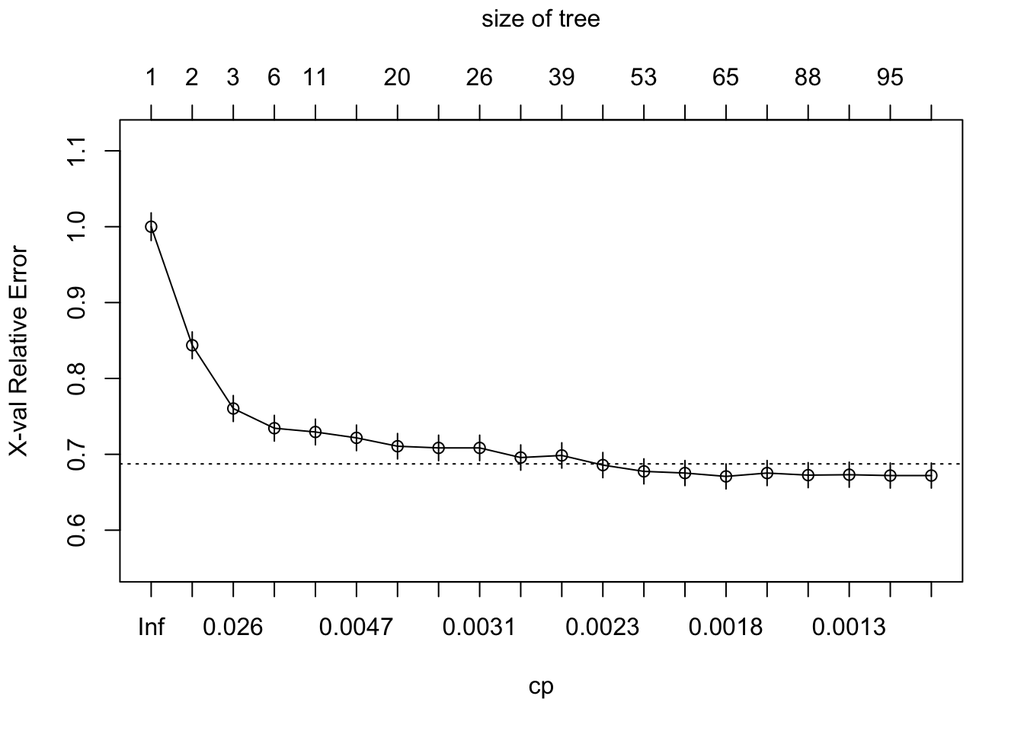

```r
plotcp(wine_CART) # visualize cross validation results
```

```r
bestcp <- wine_CART$cptable[which.min(wine_CART$cptable[,"xerror"]),"CP"]
bestcp # print best cp based on model
```

```
## [1] 0.001656543
```

Prune tree to avoid minimize overfitting

```r
# prune tree using bestcp from above
wine_CART_pruned <- prune(wine_CART, cp = bestcp)
printcp(wine_CART_pruned) # display results
```

```
##
## Classification tree:
## rpart(formula = quality.bin ~ ., data = wine_train[, -(ncol(wine_train) -
##     1)], method = "class", control = rpart.control(cp = 0.001))
##
## Variables actually used in tree construction:
##  [1] alcohol              chlorides            citric.acid
##  [4] density              fixed.acidity        free.sulfur.dioxide
##  [7] pH                   residual.sugar       sulphates
## [10] total.sulfur.dioxide volatile.acidity     winetype
##
## Root node error: 1811/4547 = 0.39828
##
## n= 4547
##
##           CP nsplit rel error  xerror     xstd
## 1  0.1601325      0   1.00000 1.00000 0.018228
## 2  0.1032579      1   0.83987 0.84373 0.017588
## 3  0.0066262      2   0.73661 0.76035 0.017109
## 4  0.0064421      5   0.71397 0.73440 0.016938
## 5  0.0049696     10   0.67753 0.72943 0.016905
## 6  0.0044174     18   0.63777 0.72170 0.016851
## 7  0.0033131     19   0.63335 0.71066 0.016773
## 8  0.0031290     21   0.62673 0.70845 0.016757
## 9  0.0030370     25   0.61347 0.70845 0.016757
## 10 0.0027609     27   0.60740 0.69575 0.016665
## 11 0.0023468     38   0.57592 0.69851 0.016685
## 12 0.0022087     44   0.56102 0.68581 0.016591
## 13 0.0020247     52   0.54279 0.67753 0.016528
## 14 0.0019326     55   0.53672 0.67532 0.016511
## 15 0.0016565     64   0.51905 0.67090 0.016476
```

[figure not shown]

```r
plot(wine_CART_pruned) # visualize cross validation results
text(wine_CART_pruned, use.n = TRUE, xpd = TRUE)
```

***

#### Evaluation

```r
# confusion matrix
predict_CART<-predict(wine_CART_pruned, wine_test, type="class")
confusionMatrix(predict_CART,wine_test$quality.bin)
```

```
## Confusion Matrix and Statistics
##
##                Reference
## Prediction      Above Average  OK Superior
##   Above Average           952 263       61
##   OK                      227 446        1
##   Superior                  0   0        0
##
## Overall Statistics
##
##                Accuracy : 0.7169
##                  95% CI : (0.6964, 0.7368)
##     No Information Rate : 0.6046
##     P-Value [Acc > NIR] : < 2.2e-16
##
##                   Kappa : 0.4086
##
##  Mcnemar's Test P-Value : 5.975e-14
##
## Statistics by Class:
##
##                      Class: Above Average Class: OK Class: Superior
## Sensitivity                        0.8075    0.6291         0.00000
## Specificity                        0.5798    0.8163         1.00000
## Pos Pred Value                     0.7461    0.6617             NaN
## Neg Pred Value                     0.6632    0.7939         0.96821
## Prevalence                         0.6046    0.3636         0.03179
## Detection Rate                     0.4882    0.2287         0.00000
## Detection Prevalence               0.6544    0.3456         0.00000
## Balanced Accuracy                  0.6936    0.7227         0.50000
```

```r
# misclassification error
mean(as.character(wine_test$quality.bin) != as.character(predict_CART))
```

```
## [1] 0.2830769
```

### (iii) C5.0

#### Model

All attributes are included in the model.  
Like the CART model, **alcohol** and **volatile.acidity** are important node splitters, with 100% use in the model. This means those two variables give the greatest loss of model prediction performance if omitted.

The next important variables are free.sulfur.dioxide and sulphates, with 79.59% and 64.37% use in the model respectively. The least important varaibles are density (9.57%), total.sulfur.dioxide (7.59%), and winetype (3.78%).

```r
# model to predict quality bin from all other factors
wine_C5<-C5.0(quality.bin~., data=wine_train[,-(ncol(wine_train)-1)]) #
summary(wine_C5)
```

```
##
## Call:
## C5.0.formula(formula = quality.bin ~ ., data = wine_train[,
##  -(ncol(wine_train) - 1)])
##
##
## C5.0 [Release 2.07 GPL Edition]      Sun Feb 14 14:10:05 2021
## -------------------------------
##
## Class specified by attribute `outcome'
##
## Read 4547 cases (13 attributes) from undefined.data
##
## Decision tree:
##
## alcohol > 10.9:
## :...volatile.acidity <= 0.53:
## :   :...free.sulfur.dioxide <= 11:
## :   :   :...winetype <= 0: Above Average (102/12)
## :   :   :   winetype > 0:
## :   :   :   :...alcohol <= 11.75: OK (34/7)
## :   :   :       alcohol > 11.75:
## :   :   :       :...free.sulfur.dioxide > 6: Above Average (24/2)
## :   :   :           free.sulfur.dioxide <= 6:
## :   :   :           :...residual.sugar <= 1.65: Above Average (4/1)
## :   :   :               residual.sugar > 1.65: OK (8/1)
## :   :   free.sulfur.dioxide > 11:
## :   :   :...alcohol <= 12: Above Average (718/125)
## :   :       alcohol > 12:
## :   :       :...fixed.acidity > 8.2:
## :   :           :...volatile.acidity > 0.445: OK (3)
## :   :           :   volatile.acidity <= 0.445:
## :   :           :   :...chlorides <= 0.087: Above Average (17/1)
## :   :           :       chlorides > 0.087: OK (2)
## :   :           fixed.acidity <= 8.2:
## :   :           :...free.sulfur.dioxide > 53:
## :   :               :...citric.acid > 0.39: Superior (3/1)
## :   :               :   citric.acid <= 0.39:
## :   :               :   :...total.sulfur.dioxide > 142: Above Average (7)
## :   :               :       total.sulfur.dioxide <= 142:
```

[output cut: 305 more lines]

```
##  100.00% volatile.acidity
##  100.00% alcohol
##   79.59% free.sulfur.dioxide
##   64.37% sulphates
##   37.89% fixed.acidity
##   33.52% chlorides
##   21.68% residual.sugar
##   13.37% pH
##   12.67% citric.acid
##    9.57% density
##    7.59% total.sulfur.dioxide
##    3.78% winetype
##
##
## Time: 0.1 secs
```

[figure not shown]

```r
plot(wine_C5, main = "C5.0 Classification Tree for Quality Bin")
```

#### Evaluation

The confusion matrix shows the performance of the C5.0 model. The numbers show how many times the quality bin was identified correctly in the test data set.  
- **Misclassification Error**: 28.05%

```r
# confusion matrix
predict_C5 <- predict(wine_C5,wine_test, type="class")
confusionMatrix(wine_test$quality.bin, predict_C5)
```

```
## Confusion Matrix and Statistics
##
##                Reference
## Prediction      Above Average  OK Superior
##   Above Average           921 252        6
##   OK                      236 472        1
##   Superior                 48   4       10
##
## Overall Statistics
##
##                Accuracy : 0.7195
##                  95% CI : (0.699, 0.7393)
##     No Information Rate : 0.6179
##     P-Value [Acc > NIR] : < 2.2e-16
##
##                   Kappa : 0.4279
##
##  Mcnemar's Test P-Value : 1.223e-07
##
## Statistics by Class:
##
##                      Class: Above Average Class: OK Class: Superior
## Sensitivity                        0.7643    0.6484        0.588235
## Specificity                        0.6537    0.8061        0.973099
## Pos Pred Value                     0.7812    0.6657        0.161290
## Neg Pred Value                     0.6316    0.7937        0.996292
## Prevalence                         0.6179    0.3733        0.008718
## Detection Rate                     0.4723    0.2421        0.005128
## Detection Prevalence               0.6046    0.3636        0.031795
## Balanced Accuracy                  0.7090    0.7272        0.780667
```

```r
# misclassification error
mean(as.character(wine_test$quality.bin) != as.character(predict_C5))
```

```
## [1] 0.2805128
```

### (iv) Random Forest

#### Model

The goal is to minimize the complexity of the random forest (i.e. fewest trees in the model) and minimize the OOB estimate of error rate.

[output not shown]

The differences in error rate are negotiable after 45 trees.

The model has a particular hard time predicting “Superior” quality.bin. The classification error for the bin is 69.12%, meaning the model predicted “OK” or “Above Average” 69.12% of the time, when in reality the wine is “Superior”.

```r
# model to predict quality bin from all other factors
wine_rf<-randomForest(quality.bin~., data=wine_train[,-(ncol(wine_train)-1)], ntree=100, importance=TRUE)
wine_rf
```

```
##
## Call:
##  randomForest(formula = quality.bin ~ ., data = wine_train[, -(ncol(wine_train) -      1)], ntree = 100, importance = TRUE)
##                Type of random forest: classification
##                      Number of trees: 100
## No. of variables tried at each split: 3
##
##         OOB estimate of  error rate: 19.66%
## Confusion matrix:
##               Above Average   OK Superior class.error
## Above Average          2409  326        1   0.1195175
## OK                      473 1202        0   0.2823881
## Superior                 92    2       42   0.6911765
```

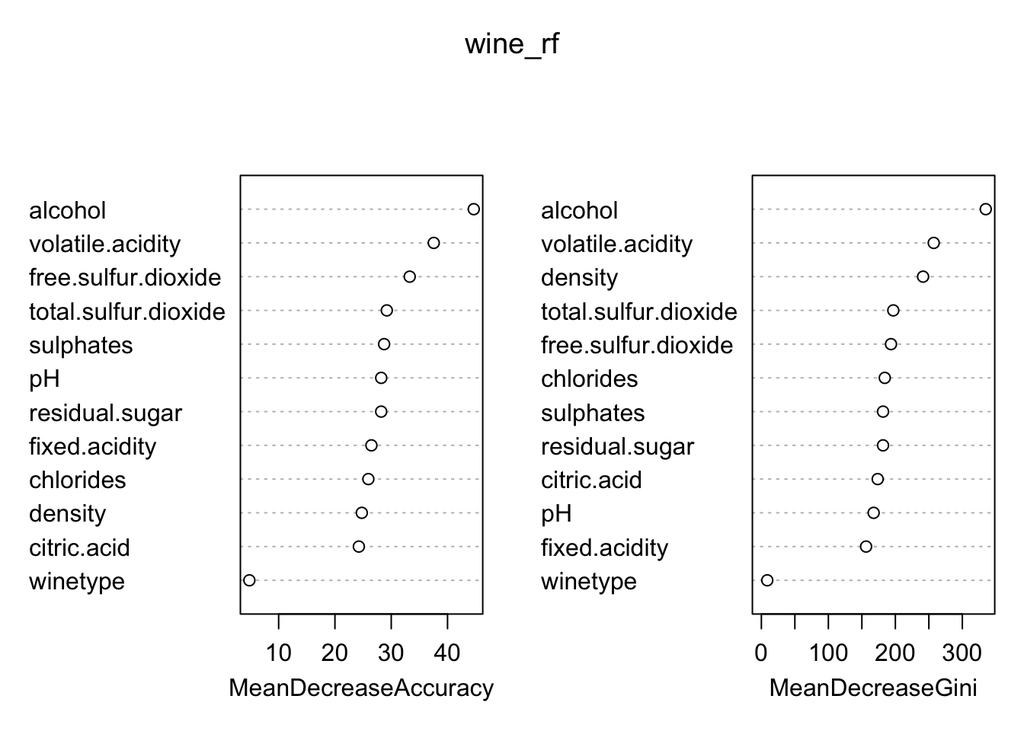

```r
varImpPlot(wine_rf)
```

#### Evaluation

```r
# confusion matrix
predict_rf<-predict(wine_rf,wine_test)
confusionMatrix(predict_rf,wine_test$quality.bin)
```

```
## Confusion Matrix and Statistics
##
##                Reference
## Prediction      Above Average   OK Superior
##   Above Average          1025  194       41
##   OK                      154  515        1
##   Superior                  0    0       20
##
## Overall Statistics
##
##                Accuracy : 0.8
##                  95% CI : (0.7815, 0.8175)
##     No Information Rate : 0.6046
##     P-Value [Acc > NIR] : < 2.2e-16
##
##                   Kappa : 0.5868
##
##  Mcnemar's Test P-Value : 4.233e-10
##
## Statistics by Class:
##
##                      Class: Above Average Class: OK Class: Superior
## Sensitivity                        0.8694    0.7264         0.32258
## Specificity                        0.6952    0.8751         1.00000
## Pos Pred Value                     0.8135    0.7687         1.00000
## Neg Pred Value                     0.7768    0.8484         0.97824
## Prevalence                         0.6046    0.3636         0.03179
## Detection Rate                     0.5256    0.2641         0.01026
## Detection Prevalence               0.6462    0.3436         0.01026
## Balanced Accuracy                  0.7823    0.8007         0.66129
```

```r
# misclassification error
mean(as.character(wine_test$quality.bin) != as.character(predict_rf))
```

```
## [1] 0.2
```

## VII. Conclusion & Recommendations

We evaluated four models to predict the quality of wine (“OK”, “Above Average” and “Superior” groupings) using 12 input variables. The accuracy of the models are shown below:

[output not shown]

**Based on our model selections, the best model to predict wine quality is Random Forest with 80% accuracy.**

This investigation could be improved in the following ways:  
**(R1)** Bin the wine quality ratings into two or four more equal groups so that the differences between the groups are not as drastic. The group Superior is decreasing the model’s accuracy in this report.

```r
table(wine$quality.bin)
```

```
##
## Above Average            OK      Superior
##          3915          2384           198
```

**(R2)** Bin the wine quality rating into two groups to utilize an ROC curve for performance.  
**(R3)** Consider other model types like AdaBoost and SVM.  
**(R4)** Consider doing a deeper analysis into decreasing the amount of predictor inputs. From this report, alcohol and volatile.acidity should be retained. However, winetype is a candidate to be cut from the predictors. Consider the correlations between the variables. During the exploration, free.sulfur.dioxide and total.sulfur.dioxide are moderately/highly correlated (r = 0.721). Perhaps our model would have been better if we left one “sulfur.dioxide” out of the analysis.